# Logistic Regression From Scratch

## Import Necessary Module

- `pandas` : Working for DataFrame
- `numpy` : For array operation
- `matplotlib` : For visualization
- `time` : function creates a valid Excel time based with supplied values for hour, minute, and second

```python
import numpy as np
import matplotlib.pyplot as plt
import pandas as pd
import time
```

Let's create the function whose name is logistic which takes x and m as parameter. x is input data and m is slope. Function returns $$ \frac{1}{1+ e^{-s}}$$ as output. Where $ s = m.x $.

For any (multi) linear equation with W as slopes, b as intercepts and X as inputs, the output y can be written as,

$$ y = XW^T+b \\ $$

Or alternatively,

$$ y = \begin{bmatrix} 1 && x_{01} && x_{02} && ... && x_{0j} \\ 1 && x_{11} && x_{12} && ... && x_{1j} \\ .. && .. && .. && ... && .. \\ 1 && x_{i1} && x_{i2} && ... && x_{ij} \end{bmatrix} * \begin{bmatrix} b \\ w_1 \\ .. \\ w_j \end{bmatrix} $$

Where 1s in the first column of the first part of multiplication represents the values of input which will be multiplied with bias.

```python
def logistic(x, m):
    x = np.dot(x, m)
    yp = 1/(1+np.exp(-x))
    return yp
```

Also, let's make function `log_loss` which take y_true and y_predict as a parameter and return $$ yt* log(yp) -(1-yt) * log(1-yp)$$ which is log_loss function of logistic regression.

```python
def log_loss(yt, yp):
    return -yt * np.log(yp) - (1-yt)* np.log(1-yp)
```

## Gradient Descent as MSE's Gradient and Log Loss as Cost Function

Here we make `gradient descent` function which take X, Y, epochs and learning rate as a parameter.

```
    X = X.reshape(-1, X.shape[-1])
    Y = Y.reshape(-1, 1)
```

Here reshape function is used to give new shape to the array. Inside reshape function `reshape(-1, x.shape[-1])` means take any rows possible but make sure column is equal to X.shape[-1]. Which simply is making sure input X has number of features equals to the number of columns.

```
    m = np.vstack([np.zeros(Y.shape[-1]), np.zeros((X.shape[-1],1))])

    X = np.hstack([np.ones((X.shape[0], 1)), X])
```

len(x) gives the length of our observation. We create list `err= []` to keep error value come from each iterations. Use for loop in epochs. Yp is the predicted value for logistic regression which is obtain by calling `logistic()` function and error is calculated from `log_loss()` function then we calculate the mean of error. Here we use tm variable which means temporary mean then we used for loop which is run on `len(m)` inside it, we calculate grad which is gradient of parameter.

Mathematically,

$$ E = \frac{1}{2m}\sum(yp- yt)^2 $$

Skipping summation sign as for calculating derivative.

$$ \frac{d(E)}{dw} = \frac{1}{2m}. 2.(y-yp).\frac{d(y-yp)}{dw}$$$$=\frac{1}{n}.{y-yp}.\frac{d(y-yp)}{d(yp)}.\frac{d(yp)}{dw}$$

also,

$$ y_p= \frac{1}{1+e^{-S}} $$

and

$$ S = X.W^T + b$$

and $$ \frac{1}{1+e^{-s}} = \frac{1}{1+e^{-s}}.\left[1- \frac{1}{1+e^{-s}}\right]$$

$$ \frac{d(yp)}{dw} = \frac{d(\frac{1}{1+e^{-s}})}{dw}$$$$=\frac{1}{n}.{y-yp}.\frac{y-yp}{d(yp)}. \frac{d(\frac{1}{1+e^{-s}})}{ds}.\frac{d(XW + b)}{dw}$$

finally, $$= -\frac{1}{n}\sum(y-yp).1.yp.(1-yp).x$$

Hence we calculate gradient of parameter j using mean square in following way,

```
grad = np.sum((yp - Y)*yp*(1-yp)*np.array(X[:,j]).reshape(n, 1))
tm[j] = m[j] - (lr / n) * grad
```

Here we update all parameters in each epoch. Before doing update, we made an empty array of shape of m where we will insert the new weights based on current weight, learning rate and gradient. We also calculate error in each iteration and keep in error list which is initialized earlier.

```
X = np.arange(0,500).reshape(-1,2)/1000
Y = X.sum(axis=1)
m=gradient_descent(X,Y, epochs=1000, lr=0.01)
```

We used our dummy data before pass real data to be sure whether it work or not after being clear our model work properly we used our real data into model. In above data our model works properly if we observe error it is going to decrease in each iteration.

```
[[0.]
 [0.]
 [0.]] [[1.    0.    0.001]
 [1.    0.002 0.003]
 [1.    0.004 0.005]
 [1.    0.006 0.007]
 [1.    0.008 0.009]
 [1.    0.01  0.011]
 [1.    0.012 0.013]
 [1.    0.014 0.015]
 [1.    0.016 0.017]
 [1.    0.018 0.019]
 [1.    0.02  0.021]
 [1.    0.022 0.023]
 [1.    0.024 0.025]
 [1.    0.026 0.027]
 [1.    0.028 0.029]
 [1.    0.03  0.031]
 [1.    0.032 0.033]
 [1.    0.034 0.035]
 [1.    0.036 0.037]
 [1.    0.038 0.039]
 [1.    0.04  0.041]
 [1.    0.042 0.043]
 [1.    0.044 0.045]
 [1.    0.046 0.047]
 [1.    0.048 0.049]
 [1.    0.05  0.051]
 [1.    0.052 0.053]
 [1.    0.054 0.055]
 [1.    0.056 0.057]
 [1.    0.058 0.059]
 [1.    0.06  0.061]
 [1.    0.062 0.063]
 [1.    0.064 0.065]
 [1.    0.066 0.067]
 [1.    0.068 0.069]
 [1.    0.07  0.071]
 [1.    0.072 0.073]
 [1.    0.074 0.075]
```

[output cut: 1197 more lines]

```
Iteration 985: Error: 0.6852858275518479
Iteration 986: Error: 0.6852782877678198
Iteration 987: Error: 0.6852707486519444
Iteration 988: Error: 0.6852632102037465
Iteration 989: Error: 0.685255672422752
Iteration 990: Error: 0.6852481353084877
Iteration 991: Error: 0.6852405988604805
Iteration 992: Error: 0.6852330630782585
Iteration 993: Error: 0.6852255279613501
Iteration 994: Error: 0.6852179935092843
Iteration 995: Error: 0.685210459721591
Iteration 996: Error: 0.6852029265978004
Iteration 997: Error: 0.6851953941374436
Iteration 998: Error: 0.6851878623400527
Iteration 999: Error: 0.6851803312051593
```

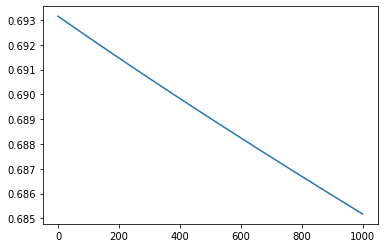

```python
def gradient_descent_mse(X, Y, epochs=100, lr=0.001):

    X = X.reshape(-1, X.shape[-1])
    Y = Y.reshape(-1, 1)



    m = np.vstack([np.zeros(Y.shape[-1]), np.zeros((X.shape[-1],1))])

    X = np.hstack([np.ones((X.shape[0], 1)), X])

    print(m, X)

    n=len(X)
    errs = []
    for i in range(epochs):

        yp = logistic(X, m)
        err = log_loss(Y, yp)
        err = np.mean(err)

        tm = np.zeros_like(m)
        for j in range(len(m)):
            grad = np.sum((yp - Y)*yp*(1-yp)*np.array(X[:,j]).reshape(n, 1))
            tm[j] = m[j] - (lr / n) * grad
        m = tm

        errs.append(err)
        print(f"Iteration {i}: Error: {err}")
    plt.plot(errs)
    plt.show()
    return m

X = np.arange(0,500).reshape(-1,2)/1000
Y = X.sum(axis=1)
m=gradient_descent_mse(X,Y, epochs=1000, lr=0.01)
```

## Gradient Descent with Logloss's Gradient

Derivation of gradient calculated using log loss. $$cost(h_\theta(x),y) = -ylog(h_\theta(x))- (1-y)log(1-h_\theta(x))..(1)$$

From first term, $$ log(h_\theta(x)) = log(\frac{1}{1 + e^{-\theta(x)}}) = log(1) - log(1 + e^{-\theta(x)}) = - log(1 + e^{-\theta(x)}) $$

From Second term,

$$ log(1- h_\theta(x)) = log(1 - \frac{1}{1 + e^{-\theta(x)}}) = log(\frac{e^{-\theta(x)}}{1 + e^{-\theta(x)}}) = log(e^{-\theta(x)}) - log(1 + e^{-\theta(x)}) = -(\theta(x)) - log(1 + e^{-\theta(x)})$$

Do partial derivatives with respect to $\theta$ in (1) $$ \frac{1}{d(\theta)}\frac{1}{m}\sum(y.log(1 + e^{-\theta(x)}) +(\theta(x)) +log(1 + e^{-\theta(x)}) - y (\theta(x))-y.log(1 + e^{-\theta(x)}) $$

$$= \frac{1}{d(\theta)}\frac{1}{m}\sum(\theta(x) +log(1 + e^{-\theta(x)}) - y (\theta(x))$$$$= \frac{1}{d(\theta)}\frac{1}{m}\sum(loge^{-\theta(x)} + log(1 + e^{-\theta(x)}) - y (\theta(x)) $$$$ = \frac{1}{d(\theta)}\frac{1}{m}\sum(log(e^{-\theta(x)} + \frac{e^{\theta(x)}}{e^{-\theta(x)}})- y (\theta(x))$$$$ = \frac{1}{d(\theta)}\frac{1}{m}\sum(log(1 + e^{\theta(x)}-y (\theta(x))$$$$ = \frac{1}{m}\sum(\frac{x e^{\theta(x)}}{1 + e^{\theta(x)}} - y(x))$$$$ = \frac{1}{m} \sum((h\theta(x)- y)x)$$

```
Iteration 0: Error: 0.6931471805599454
Iteration 1: Error: 0.6931128706520691
Iteration 2: Error: 0.6930785871711834
Iteration 3: Error: 0.6930443299990934
Iteration 4: Error: 0.6930100990182625
Iteration 5: Error: 0.6929758941118113
Iteration 6: Error: 0.6929417151635114
Iteration 7: Error: 0.6929075620577834
Iteration 8: Error: 0.6928734346796926
Iteration 9: Error: 0.6928393329149459
Iteration 10: Error: 0.692805256649887
Iteration 11: Error: 0.6927712057714943
Iteration 12: Error: 0.6927371801673762
Iteration 13: Error: 0.6927031797257686
Iteration 14: Error: 0.6926692043355303
Iteration 15: Error: 0.6926352538861401
Iteration 16: Error: 0.6926013282676936
Iteration 17: Error: 0.6925674273708989
Iteration 18: Error: 0.6925335510870742
Iteration 19: Error: 0.6924996993081429
Iteration 20: Error: 0.6924658719266327
Iteration 21: Error: 0.692432068835669
Iteration 22: Error: 0.6923982899289741
Iteration 23: Error: 0.6923645351008628
Iteration 24: Error: 0.692330804246239
Iteration 25: Error: 0.6922970972605929
Iteration 26: Error: 0.6922634140399971
Iteration 27: Error: 0.692229754481104
Iteration 28: Error: 0.6921961184811417
Iteration 29: Error: 0.6921625059379121
Iteration 30: Error: 0.6921289167497859
Iteration 31: Error: 0.6920953508157011
Iteration 32: Error: 0.6920618080351583
Iteration 33: Error: 0.692028288308219
Iteration 34: Error: 0.6919947915355019
Iteration 35: Error: 0.6919613176181786
Iteration 36: Error: 0.6919278664579727
Iteration 37: Error: 0.6918944379571547
Iteration 38: Error: 0.6918610320185401
Iteration 39: Error: 0.691827648545486
```

[output cut: 945 more lines]

```
Iteration 985: Error: 0.6649057449216961
Iteration 986: Error: 0.6648801822441182
Iteration 987: Error: 0.6648546243322733
Iteration 988: Error: 0.6648290711848167
Iteration 989: Error: 0.6648035228004061
Iteration 990: Error: 0.6647779791777018
Iteration 991: Error: 0.6647524403153671
Iteration 992: Error: 0.6647269062120674
Iteration 993: Error: 0.664701376866471
Iteration 994: Error: 0.664675852277249
Iteration 995: Error: 0.6646503324430744
Iteration 996: Error: 0.6646248173626234
Iteration 997: Error: 0.6645993070345746
Iteration 998: Error: 0.6645738014576088
Iteration 999: Error: 0.6645483006304098
```

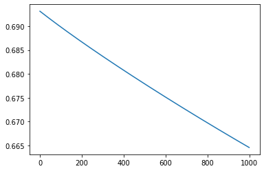

```python
def gradient_descent_ll(X, Y, epochs=100, lr=0.001):

    X = X.reshape(-1, X.shape[-1])
    Y = Y.reshape(-1, 1)

    m = np.vstack([np.zeros(Y.shape[-1]), np.zeros((X.shape[-1],1))])

    X = np.hstack([np.ones((X.shape[0], 1)), X])
    #print(X)

    #print(m.shape, X.shape)
    n=len(X)
    errs = []
    for i in range(epochs):

        yp = logistic(X, m)
        err = log_loss(Y, yp)
        err = np.mean(err)

        tm = np.zeros_like(m)
        for j in range(len(m)):
            grad = np.sum((yp - Y)*np.array(X[:,j]).reshape(n, 1))
            tm[j] = m[j] - (lr / n) * grad
        m = tm

        errs.append(err)
        print(f"Iteration {i}: Error: {err}")
    plt.plot(errs)
    plt.show()
    return m

X = np.arange(0,500).reshape(-1,2)/1000
Y = X.sum(axis=1)
m=gradient_descent_ll(X,Y, epochs=1000, lr=0.01)
```

```python
m
```

```
array([[-0.12167127],
       [ 0.36669978],
       [ 0.36657811]])
```

## Read csv Data

Here we read **Diabetes** data which is in csv file formate. In y values we pass `Diabetes` columns and in x we pass Remaining columns of dataframe.

```python
df = pd.read_csv("data/Diabetes.csv")

y = df.Diabetes
X = df[[c for c in df.columns if c!="Diabetes"]]
df.head()
```

|  | Pragnency | Glucose | Blod Pressure | Skin Thikness | Insulin | BMI | DFP | Age | Diabetes |
| --- | --- | --- | --- | --- | --- | --- | --- | --- | --- |
| 0 | 1 | 85 | 66 | 29 | 0 | 26.6 | 0.351 | 31 | 0 |
| 1 | 8 | 183 | 64 | 0 | 0 | 23.3 | 0.672 | 32 | 1 |
| 2 | 1 | 89 | 66 | 23 | 94 | 28.1 | 0.167 | 21 | 0 |
| 3 | 0 | 137 | 40 | 35 | 168 | 43.1 | 2.288 | 33 | 1 |
| 4 | 5 | 116 | 74 | 0 | 0 | 25.6 | 0.201 | 30 | 0 |

## Split data

Here we split data into train and test set in the proportion of 70% to 30%.

```python
split = int(len(df)*0.7)
train_x, test_x = X[:split].to_numpy() , X[split:].to_numpy()
train_y, test_y = y[:split].to_numpy() , y[split:].to_numpy()
```

```python
train_x.shape
```

```
(536, 8)
```

Pass our splitted data into the model

```
Iteration 0: Error: 0.6931471805599453
Iteration 1: Error: 0.6753173151381966
Iteration 2: Error: 0.670953105482409
Iteration 3: Error: 0.6680067590438291
Iteration 4: Error: 0.6658114366077005
Iteration 5: Error: 0.6641003187571228
Iteration 6: Error: 0.6627056795829591
Iteration 7: Error: 0.6615202109683567
Iteration 8: Error: 0.6604753848448818
Iteration 9: Error: 0.6595274024039177
Iteration 10: Error: 0.6586481855894578
Iteration 11: Error: 0.6578196490936163
Iteration 12: Error: 0.6570300682332401
Iteration 13: Error: 0.656271775546744
Iteration 14: Error: 0.6555396978319806
Iteration 15: Error: 0.6548304250372056
Iteration 16: Error: 0.6541416163347586
Iteration 17: Error: 0.6534716204640569
Iteration 18: Error: 0.6528192325698534
Iteration 19: Error: 0.6521835381930627
Iteration 20: Error: 0.651563813024095
Iteration 21: Error: 0.6509594583983082
Iteration 22: Error: 0.6503699597354327
Iteration 23: Error: 0.6497948597254692
Iteration 24: Error: 0.649233741001597
Iteration 25: Error: 0.6486862149210064
Iteration 26: Error: 0.6481519142802602
Iteration 27: Error: 0.6476304885660639
Iteration 28: Error: 0.6471216008401808
Iteration 29: Error: 0.6466249256776682
Iteration 30: Error: 0.6461401477840287
Iteration 31: Error: 0.6456669610499081
Iteration 32: Error: 0.6452050678877653
Iteration 33: Error: 0.6447541787502687
Iteration 34: Error: 0.6443140117658619
Iteration 35: Error: 0.6438842924499751
Iteration 36: Error: 0.6434647534651935
Iteration 37: Error: 0.6430551344132726
Iteration 38: Error: 0.642655181648053
Iteration 39: Error: 0.6422646481022992
```

[output cut: 945 more lines]

```
Iteration 985: Error: 0.6198597395805465
Iteration 986: Error: 0.6198557005987209
Iteration 987: Error: 0.6198516636254772
Iteration 988: Error: 0.6198476286581681
Iteration 989: Error: 0.6198435956941535
Iteration 990: Error: 0.6198395647308017
Iteration 991: Error: 0.6198355357654884
Iteration 992: Error: 0.6198315087955978
Iteration 993: Error: 0.6198274838185214
Iteration 994: Error: 0.6198234608316584
Iteration 995: Error: 0.6198194398324164
Iteration 996: Error: 0.61981542081821
Iteration 997: Error: 0.6198114037864619
Iteration 998: Error: 0.6198073887346024
Iteration 999: Error: 0.6198033756600692
```

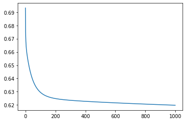

```python
m1=gradient_descent_ll(train_x,train_y, epochs=1000, lr=0.0001)
```

```
[[0.]
 [0.]
 [0.]
 [0.]
 [0.]
 [0.]
 [0.]
 [0.]
 [0.]] [[1.000e+00 1.000e+00 8.500e+01 ... 2.660e+01 3.510e-01 3.100e+01]
 [1.000e+00 8.000e+00 1.830e+02 ... 2.330e+01 6.720e-01 3.200e+01]
 [1.000e+00 1.000e+00 8.900e+01 ... 2.810e+01 1.670e-01 2.100e+01]
 ...
 [1.000e+00 1.000e+00 7.700e+01 ... 3.330e+01 1.251e+00 2.400e+01]
 [1.000e+00 4.000e+00 1.320e+02 ... 3.290e+01 3.020e-01 2.300e+01]
 [1.000e+00 0.000e+00 1.050e+02 ... 2.960e+01 1.970e-01 4.600e+01]]
Iteration 0: Error: 0.6931471805599453
Iteration 1: Error: 0.6869199809318274
Iteration 2: Error: 0.6826033734150411
Iteration 3: Error: 0.6794997322800232
Iteration 4: Error: 0.6771789327634328
Iteration 5: Error: 0.675374478619412
Iteration 6: Error: 0.6739190931542806
Iteration 7: Error: 0.6727061341852547
Iteration 8: Error: 0.6716665147124956
Iteration 9: Error: 0.6707547415009584
Iteration 10: Error: 0.6699403393435489
Iteration 11: Error: 0.6692025026431153
Iteration 12: Error: 0.668526714949407
Iteration 13: Error: 0.6679025891967096
Iteration 14: Error: 0.6673224765761495
Iteration 15: Error: 0.6667805652689832
Iteration 16: Error: 0.6662722941422985
Iteration 17: Error: 0.6657939701002062
Iteration 18: Error: 0.6653425174873706
Iteration 19: Error: 0.6649153131555291
Iteration 20: Error: 0.6645100770316368
Iteration 21: Error: 0.6641247985690558
Iteration 22: Error: 0.6637576863489002
Iteration 23: Error: 0.6634071326027736
Iteration 24: Error: 0.6630716873694631
```

[output cut: 960 more lines]

```
Iteration 985: Error: 0.6242462317717624
Iteration 986: Error: 0.624243128226086
Iteration 987: Error: 0.6242400332190873
Iteration 988: Error: 0.6242369467169946
Iteration 989: Error: 0.6242338686861796
Iteration 990: Error: 0.6242307990931567
Iteration 991: Error: 0.6242277379045825
Iteration 992: Error: 0.624224685087255
Iteration 993: Error: 0.6242216406081127
Iteration 994: Error: 0.6242186044342345
Iteration 995: Error: 0.6242155765328383
Iteration 996: Error: 0.6242125568712813
Iteration 997: Error: 0.6242095454170583
Iteration 998: Error: 0.6242065421378017
Iteration 999: Error: 0.6242035470012808
```

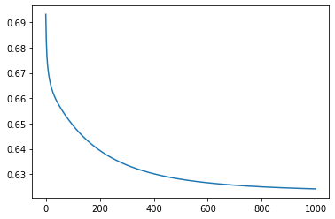

```python
m2 = gradient_descent_mse(train_x,train_y, epochs=1000, lr=0.0001)
```

```python
m1,m2
```

```
(array([[-0.00375889],
        [ 0.02025457],
        [ 0.01053516],
        [-0.02803525],
        [-0.00331913],
        [ 0.00105126],
        [ 0.00690503],
        [ 0.00053674],
        [-0.00414454]]),
 array([[-0.00094062],
        [ 0.00494987],
        [ 0.01057862],
        [-0.02389778],
        [-0.004074  ],
        [ 0.00106731],
        [-0.00077729],
        [ 0.00011566],
        [-0.00323656]]))
```

Function to determine the accuracy of model.

```python
def accuracy(y,yt):
    return np.mean((y.astype(int)==yt.astype(int)).astype(int))
```

## Predict the data

Following `predict()` function is for making prediction on train as well as untrained data. Here in`x = np.hstack([np.ones((x.shape[0], 1)), x])` and `x.shape[0]` takes only row of data and by using `hstack()` function we added 1 in each row horizontally as first column. Which is passed into logistic function. The predict function returns: if x is grater than 0.5 result 1 otherwise 0.

```python
def predict(x, m):

    x = np.hstack([np.ones((x.shape[0], 1)), x])
    x = logistic(x,m)
    return (x>0.5).astype(np.int)
```

```python
yp = predict(test_x,m1)
```

```python
accuracy(predict(test_x,m1),test_y), accuracy(predict(test_x,m2),test_y)
```

[output not shown]

## To find precision_score, recall_score, f1_score, accuracy_score

- `precision_score` : The precision is the ratio tp / (tp + fp) where tp is the number of true positives and fp the number of false positives.
- `recall_score` : The recall is the ratio tp / (tp + fn) where tp is the number of true positives and fn the number of false negatives
- `f1_score`: the F-score or F-measure is a measure of a test's accuracy

```python
from sklearn.metrics import precision_score, recall_score, f1_score, accuracy_score

print(f"Train Accuracy: {accuracy_score(train_y, predict(train_x, m1))}")
print(f"Test Accuracy: {accuracy_score(test_y, predict(test_x, m1))}")

print(f"\nTrain Precision: {precision_score(train_y, predict(train_x, m1))}")
print(f"Test Precision: {precision_score(test_y, predict(test_x, m1))}")

print(f"\nTrain Recall: {recall_score(train_y, predict(train_x, m1))}")
print(f"Test Recall: {recall_score(test_y, predict(test_x, m1))}")

print(f"\nTrain F1: {f1_score(train_y, predict(train_x, m1))}")
print(f"Test F1: {f1_score(test_y, predict(test_x, m1))}")
```

```
Train Accuracy: 0.6847014925373134
Test Accuracy: 0.6623376623376623

Train Precision: 0.6
Test Precision: 0.5161290322580645

Train Recall: 0.30319148936170215
Test Recall: 0.20253164556962025

Train F1: 0.40282685512367494
Test F1: 0.2909090909090909
```

## Using Library

```python
from sklearn.linear_model import LogisticRegression

model = LogisticRegression()

model.fit(train_x,train_y)
```

```python
model.intercept_, model.coef_
```

```python
print(f"Train Accuracy: {accuracy_score(train_y, model.predict(train_x))}")
print(f"Test Accuracy: {accuracy_score(test_y, model.predict(test_x))}")

print(f"\nTrain Precision: {precision_score(train_y, model.predict(train_x))}")
print(f"Test Precision: {precision_score(test_y, model.predict(test_x))}")

print(f"\nTrain Recall: {recall_score(train_y, model.predict(train_x))}")
print(f"Test Recall: {recall_score(test_y, model.predict(test_x))}")

print(f"\nTrain F1: {f1_score(train_y, model.predict(train_x))}")
print(f"Test F1: {f1_score(test_y, model.predict(test_x))}")
```

[output not shown]